# Semesterbegleitende Abgabe SoSe2026

# Statistik im Bachelor Wirtschaftsinformatik

Dozent_innen: Martin Spott, Michael Heimann, Anja Hirsch  
Stand: 05.05.2026

**Gruppe:**

[Gruppe_Z1G1_H]

**Autor_innen:**

[ Alnabulsi, Mohamad Anas ]  
[ Habachia, Mohamad ]  
[ Orabe, Abdalkarem ]  
[ Ibrahim, Hassan ]

## Einleitung

In diesem Semester beschäftigen wir uns mit Kraftstoffpreisen in Berlin. Dazu benutzen wir Daten von der Organisation Tankerkönig [1], die jede Preisänderung angeschlossener Tankstellenbetreiber_innen mit Zeitstempel protokolliert. In der Datei *tankerkoenigSoSe2026.csv* finden Sie den Ausschnitt der Daten, den Sie für die Aufgaben benutzen sollen. Dabei haben wir für jede Tankstelle und jede Stunde den Median der von Tankerkönig registrierten Preisänderungen der Kraftstoffe Diesel und E10 ermittelt.

### Regeln

Arbeiten Sie in Ihrer Moodlegruppe von bis zu vier Studierenden, die alle in derselben Übungsgruppe sein und die eine zu wählende Abgabe auch in den zugehörigen Übungen vorstellen müssen (Terminkalender folgt). Jede/r von Ihnen hat in Moodle nur Zugriff auf die Gruppeneinteilung Ihrer in LSF festgelegten Übungsgruppe, wo Sie sich in einer Gruppe eintragen müssen, um Punkte zu bekommen.

Bearbeiten Sie die Aufgaben fortlaufend in diesem RMarkdown-Dokument und geben es bei jeder Teilabgabe komplett als RMarkdown- und als mit Knit übersetztes HTML-Dokument ab. Stellen Sie sicher, dass das RMarkdown-Dokument auch für uns lauffähig ist. Gehen Sie dazu davon aus, dass sich auf unseren Rechnern die Daten im selben Verzeichnis befinden werden wie Ihr RMarkdown-Dokument.

Benutzen Sie nur Verfahren und Techniken, die wir in der Vorlesung besprochen haben. Sie können aber gerne komplexere Visualisierungen einsetzen, wenn dies sinnvoll erscheint.

Erklären Sie kurz Ihr Vorgehen vor jedem Codeabschnitt und interpretieren die Ergebnisse danach. Schreiben Sie Erklärungen/Interpretationen in Textform zwischen die Codeblöcke, nicht als Kommentare in die Codeblöcke. Sie können den Code aber gerne zusätzlich knapp kommentieren.

Für jede weitere Woche bekommen Sie eine Aufgabenstellung in RMarkdown, die Sie bitte in diesem Dokument fortlaufend anhängen und dort bearbeiten. Geben Sie immer das gesamte Dokument einschließlich der vorangehenden Aufgaben ab, da die Aufgaben teilweise aufeinander aufbauen und Sie vorangehende Lösungen später benötigen.

## Woche 1 – 05.05.2026

Beschreiben Sie zwischen den Codeblöcken in Textform, was Sie warum tun und was Sie herausfinden.

**a. Importieren Sie die Daten.**

```r
# WICHTIG: Die Datei tankerkoenigSoSe2026.csv muss im selben Ordner liegen!
tankerkoenig <- read.csv("tankerkoenigSoSe2026.csv")

# Einen ersten Überblick über die Datenstruktur verschaffen
str(tankerkoenig)
```

```
## 'data.frame':    441078 obs. of  13 variables:
##  $ X            : int  0 1 2 3 4 5 6 7 8 9 ...
##  $ id           : chr  "005056ba-7cb6-1ed2-bceb-6dbab19bed20" "005056ba-7cb6-1ed2-bceb-6dbab19bed20" "005056ba-7cb6-1ed2-bceb-6dbab19bed20" "005056ba-7cb6-1ed2-bceb-6dbab19bed20" ...
##  $ date         : chr  "2025-02-01" "2025-02-01" "2025-02-01" "2025-02-01" ...
##  $ time         : chr  "08:30" "09:30" "10:30" "11:30" ...
##  $ name         : chr  "star Tankstelle" "star Tankstelle" "star Tankstelle" "star Tankstelle" ...
##  $ brand        : chr  "STAR" "STAR" "STAR" "STAR" ...
##  $ street       : chr  "Steglitzer Damm 77" "Steglitzer Damm 77" "Steglitzer Damm 77" "Steglitzer Damm 77" ...
##  $ house_number : chr  NA NA NA NA ...
##  $ post_code    : int  12169 12169 12169 12169 12169 12169 12169 12169 12169 12169 ...
##  $ opening_time : chr  "07:00" "07:00" "07:00" "07:00" ...
##  $ closing_time : chr  "23:00" "23:00" "23:00" "23:00" ...
##  $ e10_median   : int  1769 1799 1779 1699 1689 1699 1749 1719 1704 1694 ...
##  $ diesel_median: int  1709 1719 1669 1609 1629 1619 1669 1644 1634 1634 ...
```

**b. Beschreiben Sie die Daten. Was sind die Merkmale, was die Merkmalsträger?**

Merkmalsträger (Untersuchungseinheit): Ein einzelner Merkmalsträger ist hier eine spezifische Tankstelle in einer ganz bestimmten Stunde. Jeder Zeile im Datensatz (jede Beobachtung) entspricht genau einer solchen Kombination aus Tankstelle und Stunde.

Merkmale (Variablen): Die Merkmale sind die für diese Träger erfassten Eigenschaften. Dazu gehören laut Einleitung die Tankstelle (z.B. ID), die Zeit (Stunde), die Marke der Tankstelle (`brand`) sowie der jeweilige Median-Preis für Diesel und E10.

**c. Geben Sie für alle Merkmale an, ob sie qualitativ/quantitativ, diskret/stetig und auf welchen Skalen sie definiert sind.**

Aus der Beschreibung des Datensatzes lassen sich folgende Einstufungen ableiten: 1. Tankstellen-Identifikator: Qualitativ, nominalskaliert. 2. Marke (`brand`): Qualitativ, nominalskaliert (Kategorien ohne natürliche Rangfolge). 3. Stunde (Zeitstempel): Quantitativ, intervallskaliert (oder verhältnisskaliert, wenn als Dauer seit einem Nullpunkt gemessen). Wird hier als diskret behandelt, da es sich um volle Stunden handelt. 4. Preise (Diesel & E10): Quantitativ, stetig, verhältnisskaliert (sie können jeden beliebigen Zwischenwert annehmen und haben einen absoluten Nullpunkt bei 0 Euro).

**d. Berechnen Sie für das Merkmal `brand` (Marke) die Tabellen mit absoluter und relativer Häufigkeit.**

Wir verwenden die Funktionen `table()` für die absoluten Zahlen und `prop.table()` für die relativen Anteile. Um das Ergebnis lesbar darzustellen, fassen wir es in einem Data Frame zusammen.

```r
# Absolute Häufigkeiten berechnen
abs_freq_brand <- table(tankerkoenig$brand)

# Relative Häufigkeiten berechnen
rel_freq_brand <- prop.table(abs_freq_brand)

# Tabelle zusammenbauen und runden
brand_tabelle <- data.frame(
  Marke = names(abs_freq_brand),
  Absolute_Haeufigkeit = as.numeric(abs_freq_brand),
  Relative_Haeufigkeit = round(as.numeric(rel_freq_brand), 4)
)

# Ausgabe der fertigen Tabelle
brand_tabelle
```

```
##           Marke Absolute_Haeufigkeit Relative_Haeufigkeit
## 1      AGIP ENI                28729               0.0651
## 2          ARAL                54508               0.1236
## 3          ESSO                28937               0.0656
## 4           HEM                41605               0.0943
## 5           JET                34444               0.0781
## 6         Shell                98465               0.2232
## 7        Sprint                34005               0.0771
## 8          STAR                53461               0.1212
## 9 TotalEnergies                66924               0.1517
```

**e. Stellen Sie die Tabelle absoluter Häufigkeit von `brand` als Balkendiagramm dar. Beschriften Sie alle Axen und geben dem Diagramm eine Überschrift.**

Wir nutzen die Funktion `barplot()`. Mit dem Argument `las = 2` stellen wir sicher, dass die Namen der Marken senkrecht geschrieben werden, falls es viele Marken gibt und der Platz sonst nicht reicht.

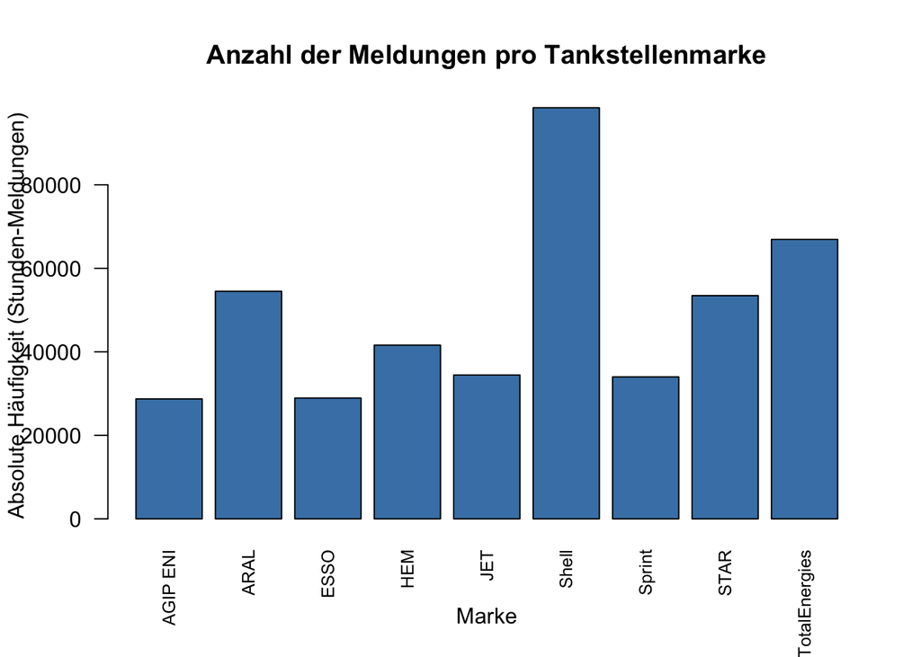

```r
# Balkendiagramm zeichnen
barplot(abs_freq_brand,
        main = "Anzahl der Meldungen pro Tankstellenmarke",
        xlab = "Marke",
        ylab = "Absolute Häufigkeit (Stunden-Meldungen)",
        col = "steelblue",
        las = 2,           # Dreht die Beschriftung der x-Achse um 90 Grad
        cex.names = 0.8)   # Macht die Schrift der Achse etwas kleiner
```

**f. Was bedeuten die absoluten Häufigkeiten im Kontext unserer Daten? Warum gibt es Unterschiede zwischen den Werten der verschiedenen Marken?**

Die absoluten Häufigkeiten geben nicht nur die reine Anzahl der Tankstellen pro Marke an. Da unsere Merkmalsträger eine Kombination aus “Tankstelle” und “Stunde” sind, zeigt die absolute Häufigkeit, wie viele stündliche Preismeldungen insgesamt von einer bestimmten Marke im Datensatz vorliegen.

**Unterschiede zwischen den Marken** kommen hauptsächlich durch zwei Dinge zustande: 1. Unterschiedliche Marktanteile: Große Anbieter (wie Aral oder Shell) haben deutlich mehr Tankstellen in Berlin als kleinere Anbieter. Mehr Tankstellen produzieren pro Stunde auch mehr Datensätze.

2. Öffnungszeiten und Verfügbarkeit: Wenn Tankstellen nachts geschlossen sind oder ihre Preise nicht durchgehend übermitteln, fehlen für diese Stunden die Meldungen. Marken mit vielen 24/7-Tankstellen generieren also verhältnismäßig mehr Datensätze.

**—Fügen Sie hier kommende Aufgabenbeschreibungen mit Lösungen ein —**

## Quellen

[1] Tankerkönig UG, URL: https://tankerkoenig.de, letzter Aufruf: 27.04.2026